# COVID-19: A Midwestern Reporting Project of WNIN and the University of Evansville

Louisville ZIP Code Analysis

Analysis performed by Maya Frederick, Timmy Miller, Ethan Morlock, Pearl Muensterman, and Darrin Weber, Ph.D.

## Background

The goal of this analysis is to find any connections, if they exist, between demographic data and the outbreak of COVID-19 in the city of Louisville. Demographic data was obtained from the Census Bureau through their 5-year American Community Survey published in 2018 (the most recent 5-year data available). COVID-19 case numbers were obtained from the Louisville Metro Department of Public Health and Wellness (https://covid-19-in-jefferson-county-ky-lojic.hub.arcgis.com/).

Throughout the document, we report the $p$-value for several statistical tests. This does nothing more than provide a measure on the amount of evidence we have to suggest statistical significance. The closer the $p$-value is to 0 the stronger the evidence that our measure (correlation most of the time) is different than 0.

**Conclusions:** Through correlation and visualization tests, we found that the rate of COVID has a moderate relationship to income, age, population of essential workers, and race; and a strong relationship to health insurance coverage and citizenship. We also found that while having private health insurance is not related linearly to COVID, it does have a relationship when combined with the geographical location. A person who knows Louisville might be able to shed some better light on this aspect. We also looked at the Gini index (a measure of income inequality), use of public transporation, and public health insurance, all of which had no evidence to support a relationship.

Of particular note is ZIP code 40202. This ZIP has an unusually high case rate of COVID, although the other demographic characteristics of this ZIP code are not extreme. The exception to that is the Gini index, where ZIP 40202 has a large inequality situation, and use of public transportation, where a higher percentage of residents use public transportation.

## Analysis

### COVID

We first look at the COVID cases by ZIP codes. We can see that ZIP 40202 has a much higher rate than the other ZIP codes. We end up having to run our analysis without this ZIP code. However, it is far beyond the extreme in the Gini Index and public transportation compared to other ZIPs. With income, private health insurance, and public health insurance it is one of the more extremely ZIP codes, but with the other demographics, it is right in the middle of the distribution. The scatterplots help to illustrate this fact.

[interactive chart not shown]

### Income

We look at the income data in increments designated by the Census Bureau. We calculated the proportion of people making over $100,000 to order the ZIP codes on the $x$-axis in the following graph.

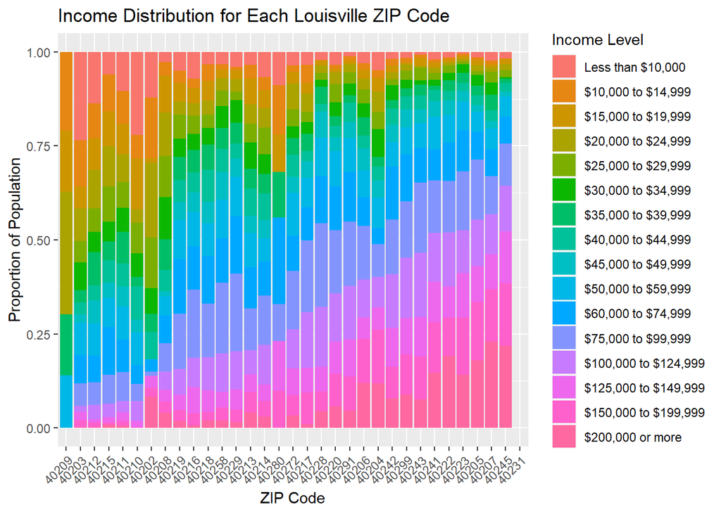

ZIP code 40231 has no data, which is true throughout the analysis.

The next graph shows that it appears to have some correlation, i.e., the poorer the ZIP code the more likely to have a higher rate of infection.

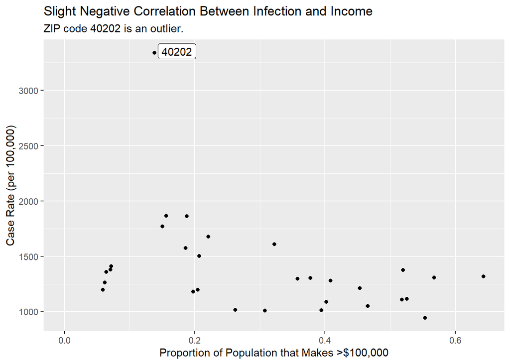

The 40202 ZIP code is a clear outlier. We remove this from the data to run a viable correlation test between the case rate and the proportion of the population that makes over $100,000. We get a statistically significant ($p=$ 0.019959) correlation value of -0.429822. This verifies that there is indeed a moderately negative correlation with case rate and higher incomes.

### Gini Index

The Gini index is a measure of income inequality calculated by the Census Bureau using various different factors. The closer to 0 the Gini index, the more equal income is dispersed. A Gini index of 1 would indicate perfect inequality where a single group or individual collects all of the income.

Below, we map the Gini index onto each ZIP code to give an idea of the variation between ZIP codes.

[interactive chart not shown]

We also provide a scatterplot to visualize the connection between COVID case rate and the Gini Index. As we can see, ZIP code 40202 is an outlier and will be removed in future analysis.

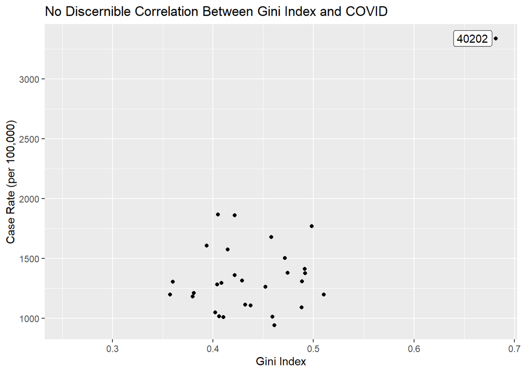

After removing 40202, we see that there is no real correlation between the Gini Index and the rate of infection for COVID. We get a correlation of 0.077903 ($p=$ 0.687922), and thus indistinguishable from 0.

### Health Insurance Coverage

We looked at the how much of the population has health insurance, regardless of whether it was public or private. The graph below shows the distribution of health insurance coverage across the Louisville ZIP codes.

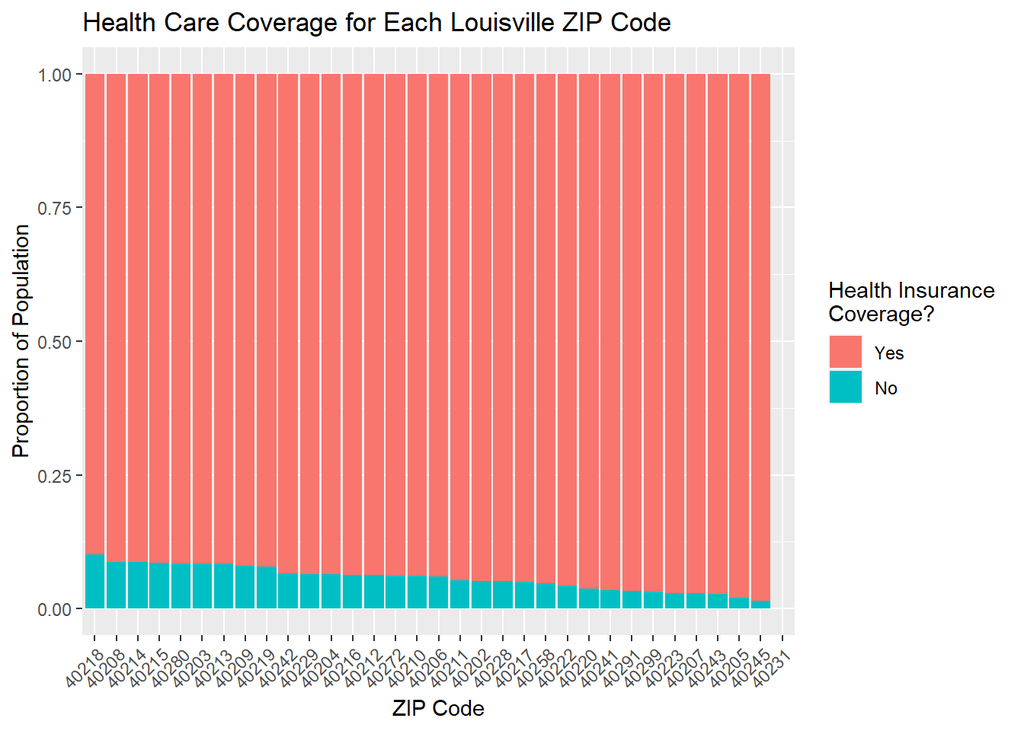

A vast majority of Louisville residents have health insurance, although there is quite a distinction between the 40218 ZIP code and the 40245 ZIP code. To see any correlation with COVID, we can look at a scatterplot.

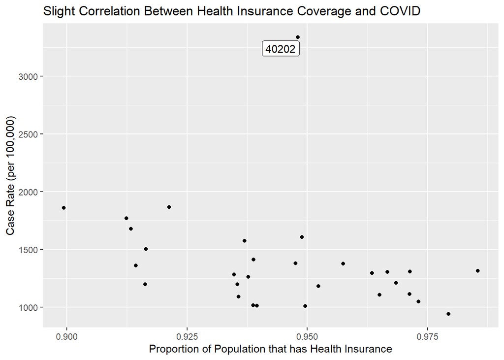

There appears to be a definitive correlation, once we remove 40202. We end up with a moderate to strong correlation value of -0.584106 ($p=$ 0.00088).

### Private Health Insurance vs. Public Health Insurance

Since access to private health insurance is not universal, we looked at the relationship between having some type of private health insurance and COVID as well as similarly looking at public health insurance. It is possible to have both public and private insurance, so these metrics are not mutually exclusive.

#### Private Health Insurance

We breakdown each ZIP code by the proportion of residents who have private health insurance.

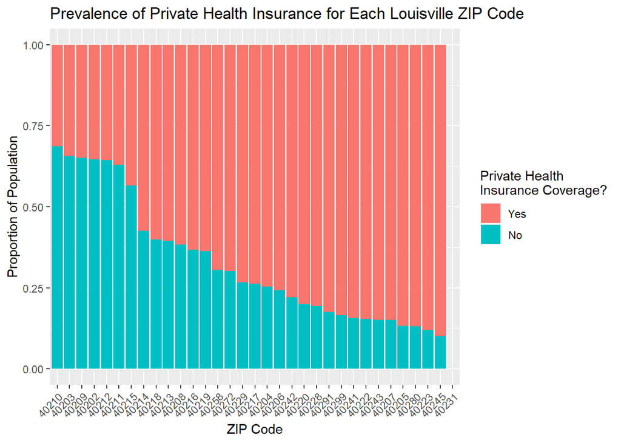

As we see, there is a wide range of those populations that have private health insurance, ranging from almost 90% of the population in 40245 to only 31.4% of the residents in 40210 having private health insurance. But how does this relate to COVID cases?

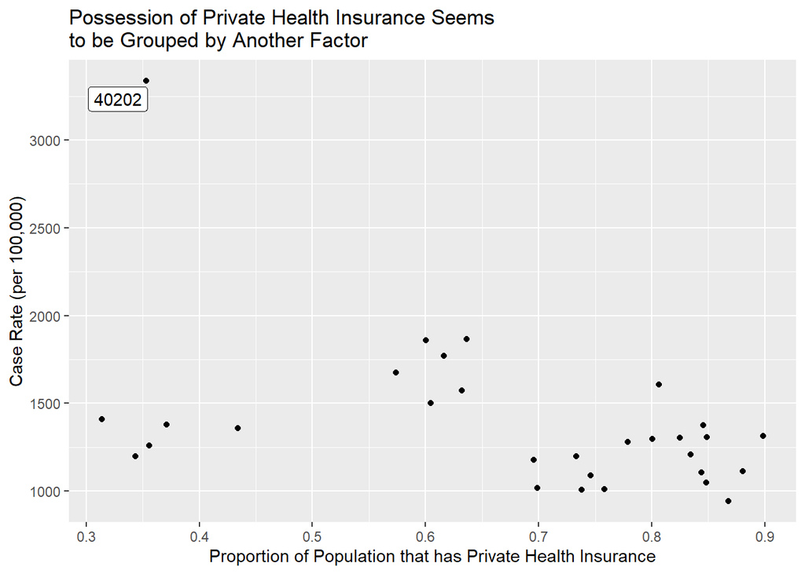

The graph shows that we don’t have a correlation between the case rate of COVID and having private insurance. However, this grouping is interesting. It turns out it is geographically based as the next map shows. We split the proportion of private health insurance into three groups: low, medium, and high. The *low* group has less than 45% of its population possessing private health insurance. The *medium* group has between 45% and 65%, and the *high* group has over 65% of its population with private health insurance.

[interactive chart not shown]

#### Public Health Insurance

We breakdown each ZIP code by the proportion of residents who have public health insurance.

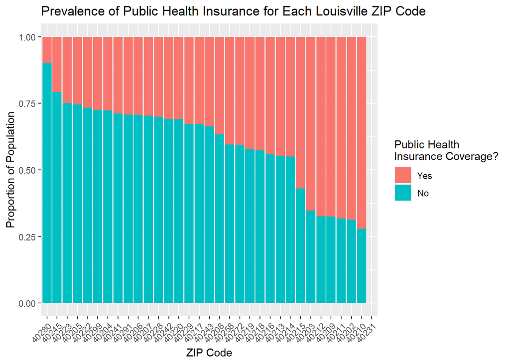

We still have a descent distinction between ZIP codes as to the proportion of their populations that have public insurance, although it is not as pronounced (ranges from almost 10% to 72%). We can look at how these proportions relate to COVID in the following plot.

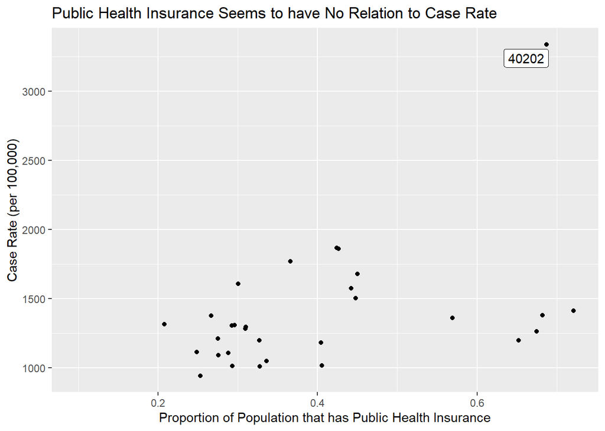

We don’t see the same groupings as we did before, but there are still 5 ZIP codes that are separated from the rest. Again, it looks as though geography (and all that it encompasses) explains this:

[interactive chart not shown]

We do not have enough evidence to suggest that COVID cases and public health insurance are related. Our correlation value is with a high $p$-value (0.18193).

### Age

We start with our basic graphic displaying the distribution of ages throughout the ZIP codes.

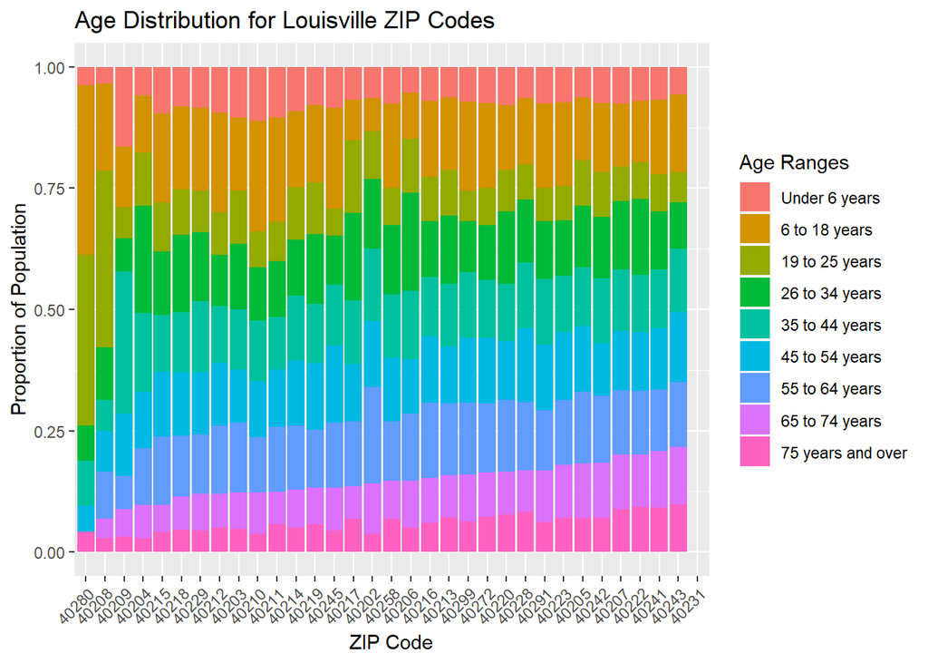

We focus on the relationship between COVID cases and the proportion of the population that is 65 years or older.

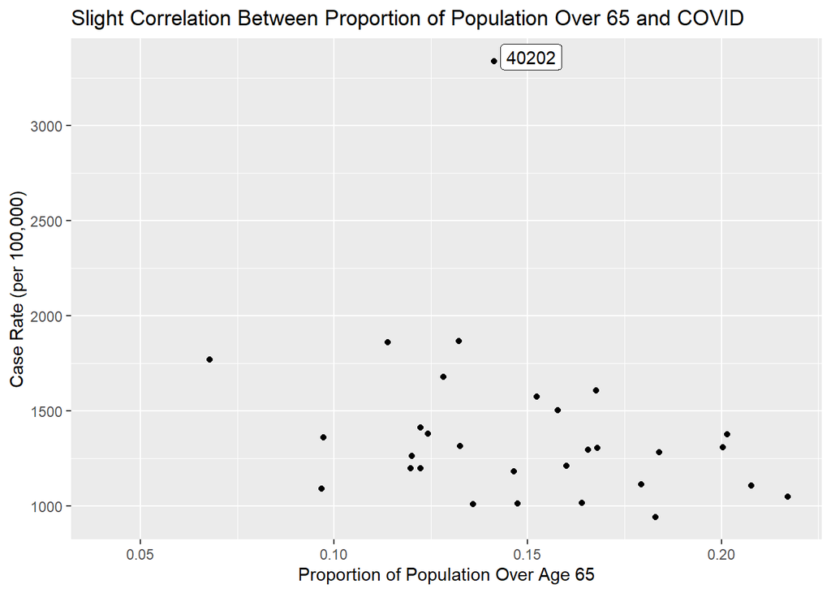

### Occupation

Many “essential” workers tend to be towards the lower end of the income bracket. We look at whether there is a relationship between essential workers and contracting COVID.

The Census Bureau breaks workers into five categories: Management, business, science and arts; service; sales and office; natural resources, construction, and maintenance; and production, transportation, and material moving. Although these categories undoubtedly may not be clear distinctions between essential and non-essential, we feel a good classification is to put natural resources, construction, and maintenance and production, transportation, material moving as essential and the other three categories as non-essential.

When we do, we get the following breakdown by ZIP code.

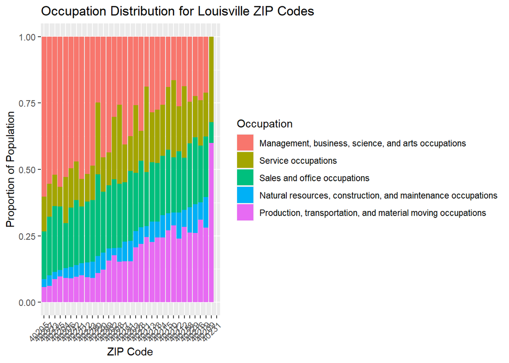

ZIP code 40209 clearly has a distinguishing percentage of production, transportation, and material moving occupations. Unfortunately, Jefferson County Health Department has not COVID information on 40209. However, we still have a good spread of different occupations from ZIP code to ZIP code. We can compare the proportion of a ZIP code that has a designated essential job to the COVID case rate.

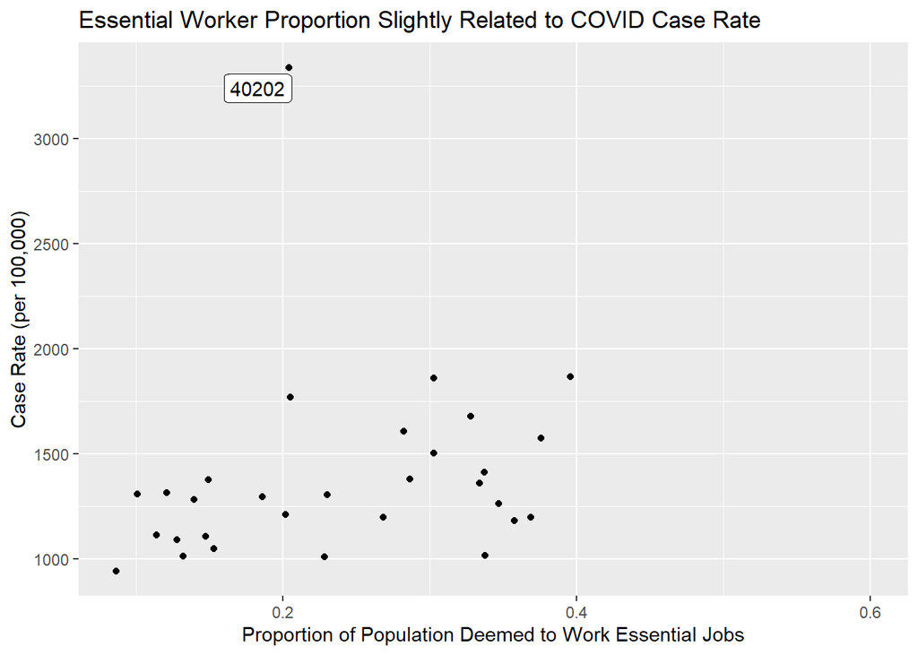

We find a moderate correlation of 0.474056 ($p=$ 0.009379).

### Public Transportation

The use of public transportation is more prevalent among lower incomes, while at the same time public transportation poses a higher risk of contracting COVID. We look to see if this idea plays out in the data for Louisville.

First, we look at the distribution of the population that uses public transportation broken down by ZIP.

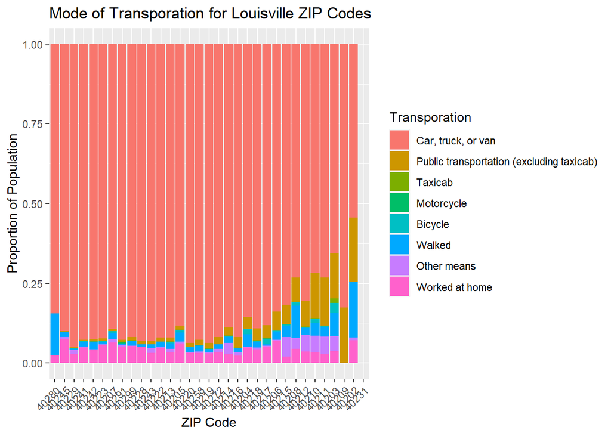

For our analysis, we grouped “Public transportation (excluding taxicab)” and “Taxicab” together to form our public use variable. It’s relationship to COVID can be seen in the following graph.

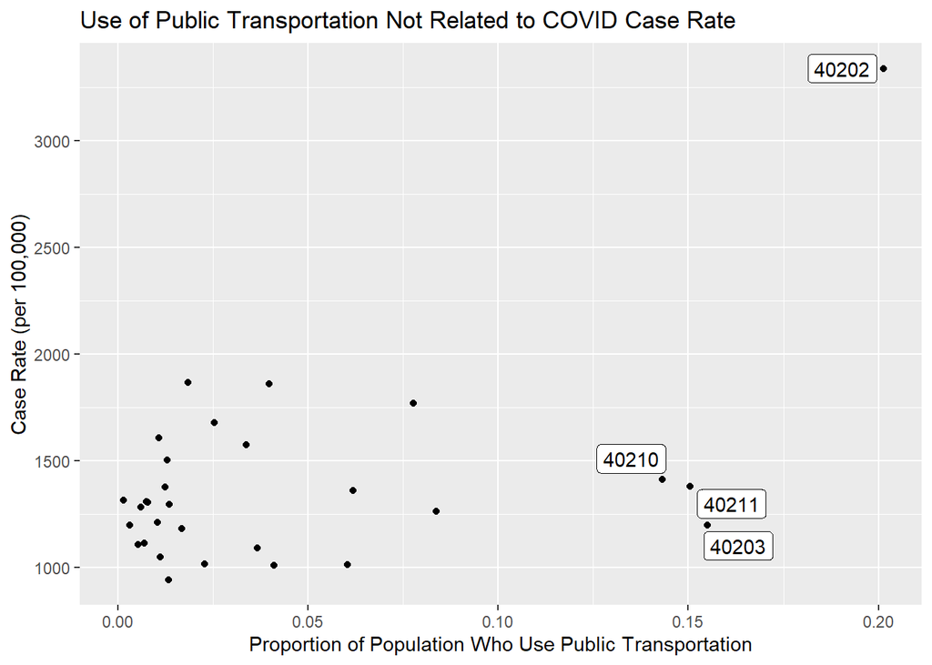

### Citizenship

The Census Bureau provides a distinction between different types of U.S. citizenship (e.g., naturalization, born in U.S., born abroad, etc.). We focus on the simple distinction between being a U.S. citizen and not.

Looking at the breakdown of the U.S. citizenship population in each ZIP code we see the expected high rates of citizenship in all ZIP codes. This ranges from 87.6% to 100% of the population being a U.S. citizen.

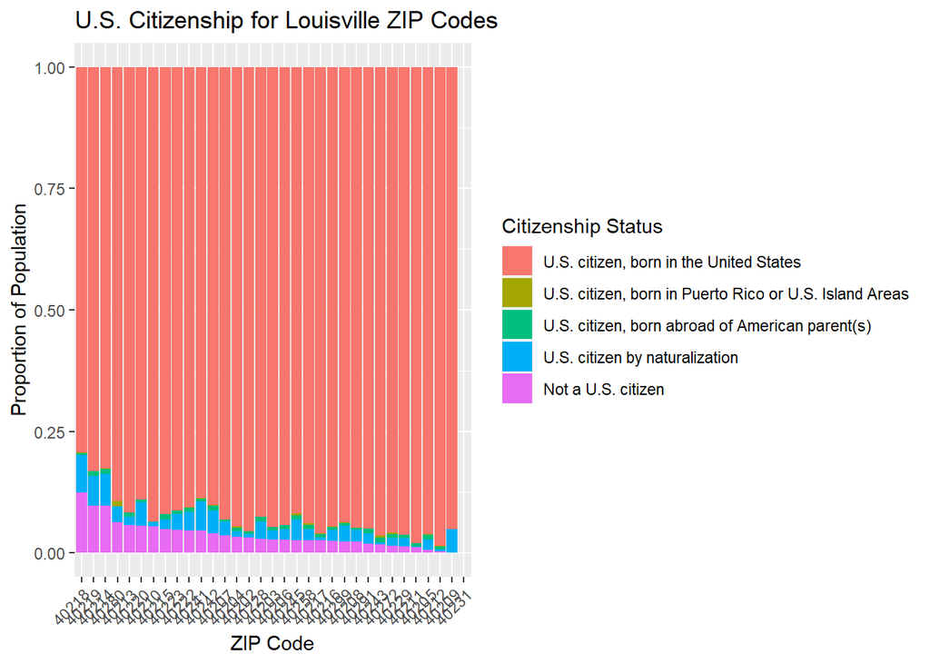

Even with high rates of citizenship, we see some correlation and grouping.

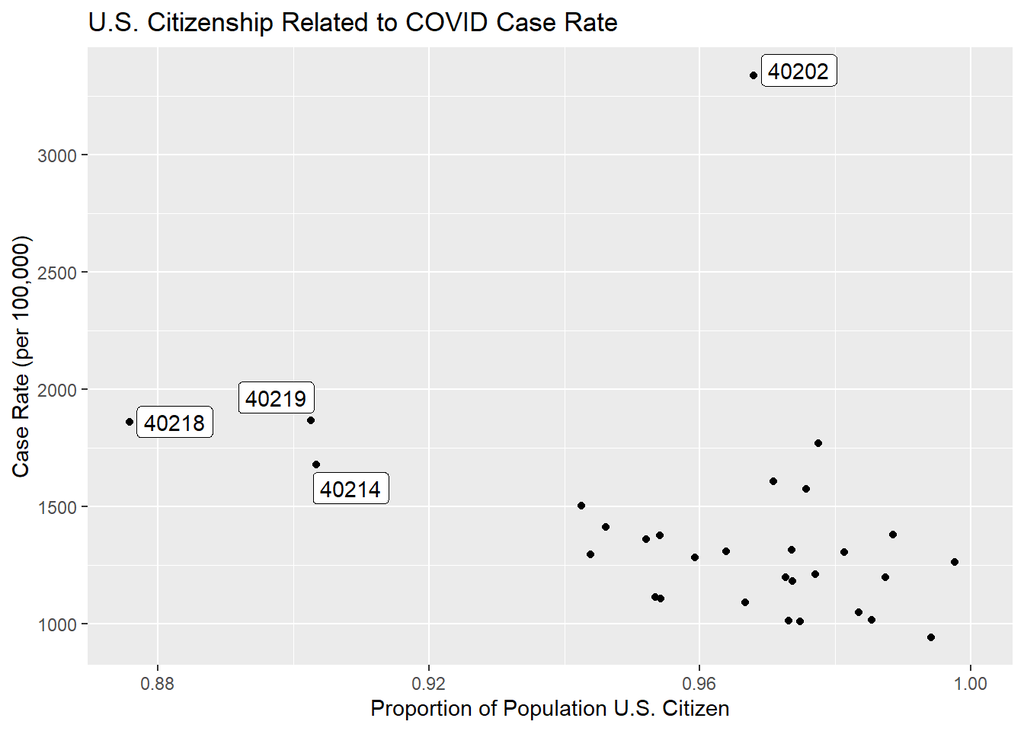

There are three ZIP codes that have a distinctively different proportion of their population which are U.S. citizens. These ZIP codes are connected geographically, but not in a seemingly meaningful way. This group, however, fits in with the trend line of the relationship by proportion of U.S. citizens and COVID cases. We get a moderate to strong correlation of -0.651685 ($p=$ 0)

### Race

Lastly, we looked at racial breakdown in each ZIP code. We’ve heard reports about black people being hit harder by COVID. We look to see if the data supports that in Louisville.

We view the racial breakdown in each ZIP code. There are significant differences in several of the ZIP codes.

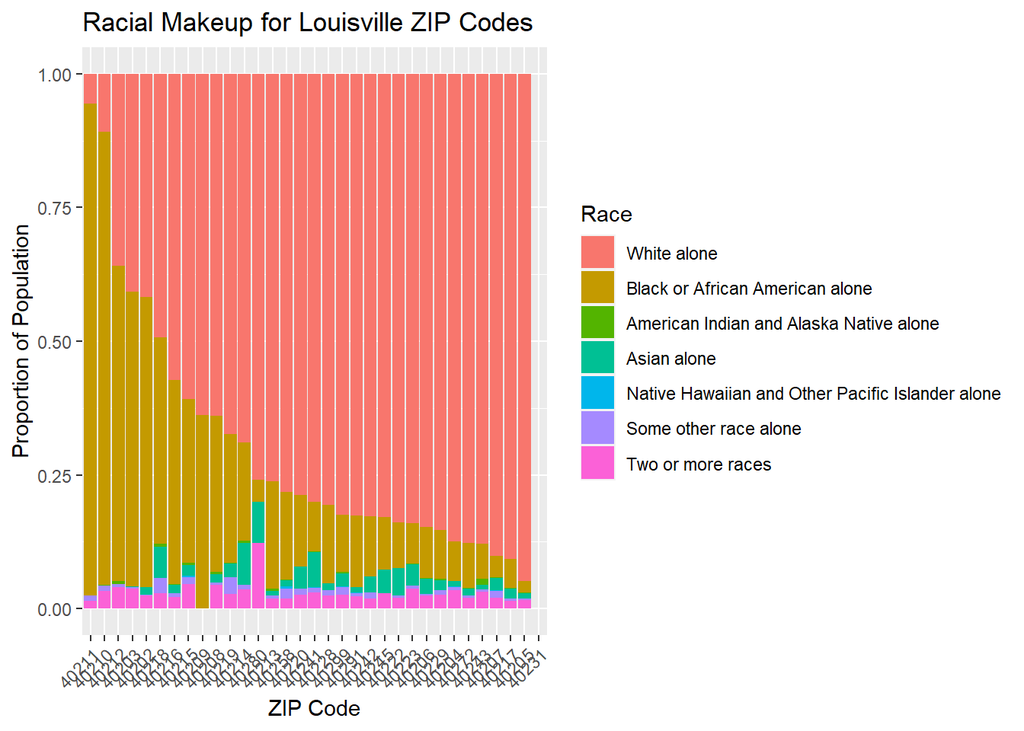

For the most part, the rates of “White alone” and “Black or African American alone” are inversely related as the other races remain somewhat constant. As a result, we can focus on the “White alone” population as a measure of the racial breakdown for each ZIP and compare it to the COVID cases.

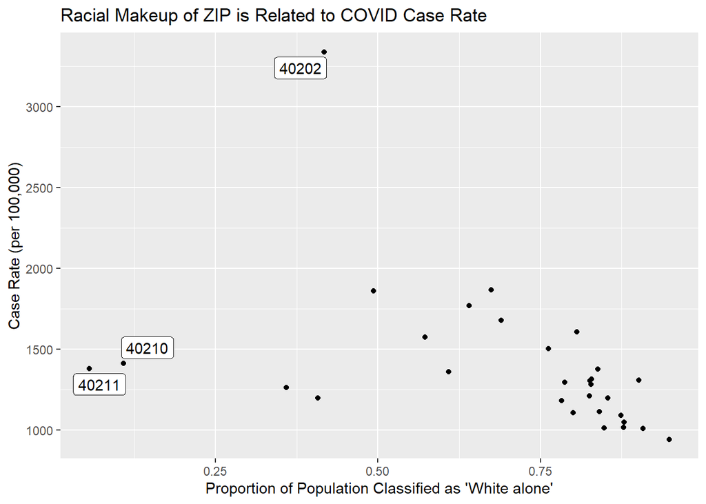

We see a moderate relationship between racial dispersion in ZIP codes and COVID with a correlation value of -0.404261 ($p=$ 0.026713).

## Conclusions

The ZIP code 40202 is a statistical outlier for it’s high case rate of COVID. This ZIP corresponds to downtown Louisville right on the Ohio River. Interestingly enough, it is not an extreme ZIP in the other categories we investigated except for Gini Index and use of public transportation. A deeper investigation with someone who knows the Louisville area better might be in order for this particular ZIP code.

Of the correlations we found, they were of the expected direction (e.g., fewer U.S. citizens correspond to higher case rates). We found strong correlations between COVID and health insurance coverage (no distinction between public and private) as well as citizenship status. We also found moderate correlations with income, age, occupation (essential vs. non-essential), and race.

An interesting phenomenon arose when looking at the proportion of people with private health insurance. When combined with the COVID data, there were three distinct groups. These groups corresponded with geography where the lower rates of private health insurance being downtown, the medium rates surrounding those ZIP codes, and the highest rates on the outskirts of the city limits.

Although we investigated the Gini index, use of public transporation, and public health insurance, we found no detectable relationship with COVID.

*Disclaimer* We looked at basic one-on-one correlations. There may be some more complex relationships that involve multiply demographics. Further analysis would be needed in order to determine if we have multiple factors playing a role together.